# Gene expression Deconvolution for human PDACA SRT datasets

Jia-Juan Tu

## Import library

```r
remove(list= ls())
library(ggplot2)
library(ggthemes)
library(scatterpie)
library(cowplot)
library(gridExtra)
library(viridis)
library(ggpubr)
library(rstatix)

library(RColorBrewer)

require(clusterProfiler)
require(org.Hs.eg.db)

require(dplyr)
library(stringr)
library(purrr)
library(stringr)

library(nichenetr)
library(tidyverse)
library(circlize)

library(tibble)


# Load necessary libraries
library(parallel)
library(doParallel)
library(glmnet)
```

### Load function

```r
source("./code/STged.R")
source("./code/benchmark.R")
source("./code/Module.R")
```

```r
geneinfor <- readRDS("./realdata/gene_entrez_info.RDS")
species = "Human"
entriz = geneinfor[geneinfor[,3]%in%species,]
```

```r
qual_col_pals = brewer.pal.info[brewer.pal.info$category == 'qual',]
col_vector  <-  unlist(mapply(brewer.pal, qual_col_pals$maxcolors,
                              rownames(qual_col_pals)))
```

### load data

```r
datax = readRDS("./realdata/PDAC/PDACA_all.RDS")

stged = readRDS("./results/PDAC/small/model.est.rds")
```

```r
ctexp  = stged$F_list
beta.type = stged$beta
colnames(beta.type)
```

```
##  [1] "Acinar cells"              "Cancer clone A"
##  [3] "Cancer clone B"            "Ductal antigen presenting"
##  [5] "Ductal centroacinar"       "Ductal high hypoxic"
##  [7] "Ductal terminal"           "Endocrine cells"
##  [9] "Endothelial cells"         "Fibroblasts"
## [11] "Macrophages A"             "Macrophages B"
## [13] "Mast cells"                "mDCs A"
## [15] "mDCs B"                    "Monocytes"
## [17] "pDCs"                      "RBCs"
## [19] "T cells and NK cells"      "Tuft cells"
```

```r
cell_type = colnames(beta.type)
ind_spot =datax$spot_exp>0

ind = beta.type[,2]>0.05


st_exp_raw = ctexp[[2]]  #*ind_spot


colnames(st_exp_raw) = rownames(beta.type)

rownames(st_exp_raw)=  gsub("(^|[[:space:]])([[:alpha:]])", "\\1\\U\\2",
                            tolower(rownames(st_exp_raw )), perl = TRUE)



st_exp  = st_exp_raw[,ind ]
#

datax$spot_loc = datax$spot_loc[rownames(beta.type),]
datax$srt_exp = datax$srt_exp[ ,rownames(beta.type)]


spot_loc_raw  = datax$spot_loc
```

```r
col_df <- data.frame(cell_types = c(cell_type,"Others"),
                     col_vector = c(col_vector[1:length(cell_type)],"gray"))
```

##get the estimated data

```r
#load data set
spot_loc = spot_loc_raw[ind ,]
beta = beta.type[ind ,]

cell_type = colnames(beta)

target  = j = cell_type[2]
target
```

```
## [1] "Cancer clone A"
```

```r
piedata_temp <- data.frame(x = as.numeric(spot_loc_raw$x),
                           y= as.numeric(spot_loc_raw$y),
                           group =factor(1:length(spot_loc_raw$x)))

pos_pie = as.data.frame(beta.type )

piedata = cbind(piedata_temp,pos_pie)


p1 = ggplot() +
  geom_scatterpie(aes(x=x, y=y, group=group),
                  cols= names(piedata)[-1:-3],
                  data = piedata, color=NA,
                  pie_scale = 0.8) +
  coord_equal() +
  theme_bw() +
  labs(y=" ", x=" ", title ="Distribution of cell type proportion") +
  theme(
    axis.ticks.x  = element_blank(),
    axis.ticks.y  = element_blank(),
    axis.text.x.bottom = element_blank(),
    axis.text.y.left = element_blank(),
    legend.text = element_text(size = 10, angle = 0.5),
    legend.position = "bottom",  # Set legend at the bottom
    legend.direction = "vertical",
    legend.title = element_blank(),
    panel.grid.small = element_blank(),
    panel.grid.minor = element_blank(),
    panel.border = element_blank(),
    axis.line = element_blank(),
    plot.title = element_text(hjust = 0.5, size = 12)  # Centering title
  ) +
  scale_fill_manual(values = col_df$col_vector, breaks = col_df$cell_types) +
  guides(fill = guide_legend(nrow = 3))
```

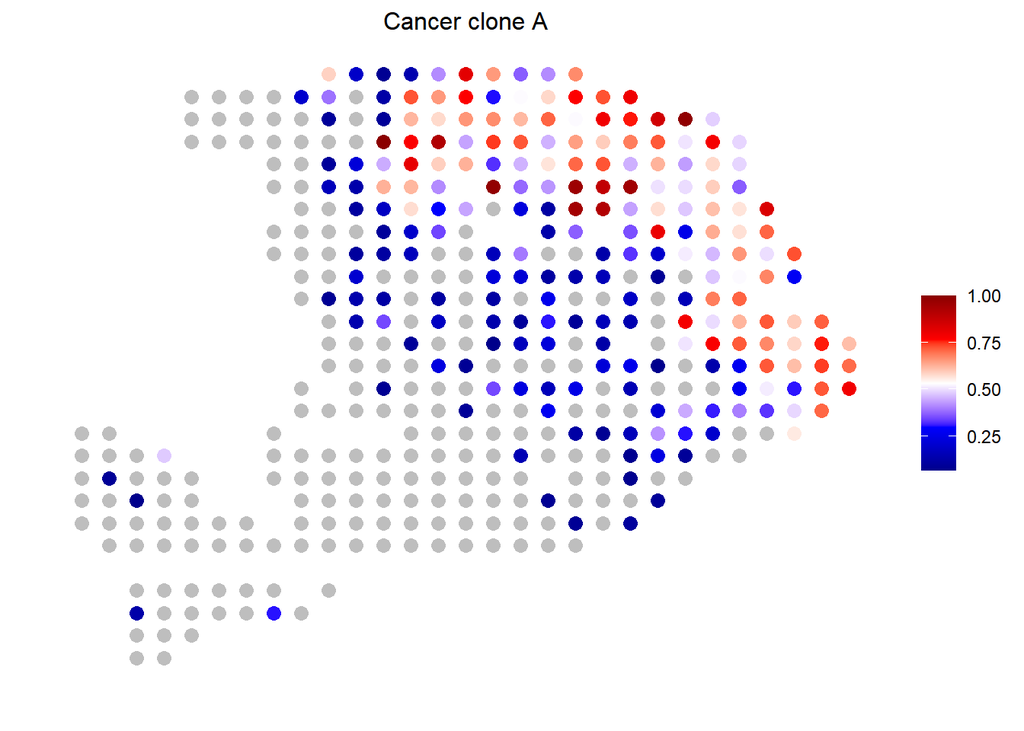

```r
# Prepare data
data_weight = data.frame(x = as.numeric(spot_loc_raw$x), y= as.numeric(spot_loc_raw$y),
                         prop  = beta.type[,j]/max(beta.type[,j]))


data_weight$color <- ifelse(data_weight$prop == 0, "gray", NA)

 p2 = ggplot(data = data_weight, aes(x = x, y = y)) +
  geom_point(aes(color = prop), size = 3, data = subset(data_weight, prop != 0)) +
  geom_point(color = "gray", size = 3, data = subset(data_weight, prop == 0)) +
  scale_color_gradientn(colours = c("darkblue", "blue", "white", "red", "darkred")) +
  labs(y = "", x = " ", title = as.character(j),
       color = "", size = "") +
  theme_classic() +
  theme(
    axis.ticks = element_blank(),
    axis.text = element_blank(),
    panel.border = element_blank(),
    axis.line = element_blank(),
    plot.title = element_text(hjust = 0.5, size = 12),  # Centering title
    legend.position = "right"
  )
 p2
```

# mHVG estimation analysis

## prepare the input

```r
st_exp  = st_exp_raw[,ind ]

dim(st_exp)
```

```
## [1] 9923  220
```

```r
Y_input = t(cleanCounts (st_exp, clean.only =TRUE) )

dim(Y_input)
```

```
## [1]  220 9537
```

```r
dim(beta)
```

```
## [1] 220  20
```

```r
neighbor =  colnames(beta)[colSums((beta!=0)*1)>(ncol(st_exp)*0.1)]

X_input = beta[,neighbor]
X_input = X_input[,-match(target, colnames(X_input))]
neighbor_sec = colnames(X_input)
neighbor_sec
```

```
##  [1] "Acinar cells"         "Cancer clone B"       "Ductal centroacinar"
##  [4] "Ductal high hypoxic"  "Ductal terminal"      "Endothelial cells"
##  [7] "Fibroblasts"          "Macrophages A"        "RBCs"
## [10] "T cells and NK cells" "Tuft cells"
```

```r
Y_scaled <- scale(Y_input)

file_path <- './results/PDAC/small/mHVG_elastic_est.RDS'

# Check if the file exists
if (!file.exists(file_path)) {
  # If the file doesn't exist, run the following code

  mHAG_est <- mHAG_func(X_scaled = X_input,
                        Y_scaled = Y_scaled,
                        alpha = 0.5,
                        num_cores = 10)

  # Save the result
  saveRDS(mHAG_est, file = file_path)
} else {
  # If the file exists, print a message
  mHAG_est = readRDS('./results/PDAC/small/mHVG_elastic_est.RDS')
}
```

```r
mHAG_est_nor = mHAG_est
mHAG_est_nor[abs(mHAG_est_nor)<1e-5]=0
mHVG <- get_non_zero_gene_names(mHAG_est_nor)

length(mHVG)
```

```
## [1] 935
```

```r
cat("number of mHVGs=",  length(mHVG), "\n")
```

```
## number of mHVGs= 935
```

```r
coeff = t(mHAG_est_nor[,mHVG])
coeff_ind = coeff > 0
```

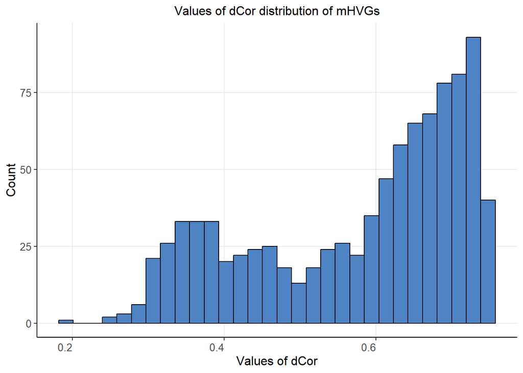

```r
result <- sapply(1:length(mHVG), function(i) {
  energy::dcor(Y_scaled[, mHVG[i]], X_input)
})


dcor.bar = ggplot(data = data.frame(x = result), aes(x = x)) +
    geom_histogram(fill = "#4E84C4",bins = 30, color = "black")+ theme_bw()+
    labs(y = "Count" , x = "Values of dCor",
         title =  "Values of dCor distribution of mHVGs" )+
    theme(
      axis.text.x.bottom = element_text(size = 10,hjust = 1),
      axis.text.y.left = element_text(size = 10),
      axis.title.x = element_text(size = 12, hjust = 0.5),
      axis.title.y = element_text(size = 12),
      plot.title = element_text( size=12,hjust = 0.5),
      panel.grid.small = element_blank(),
      panel.grid.minor = element_blank(),
      panel.border = element_blank(),
      axis.line = element_line(colour = "black"))

print(dcor.bar)
```

## ctHVG

```r
ctHVG_est = ctHVG_func(X  = X_input, Y  = Y_scaled[,mHVG], coeff_ind = coeff)

adjusted_t_p_values =  apply(ctHVG_est$pvalues,2,p.adjust)

adjusted_t_p_values[is.na(adjusted_t_p_values)] = 1

apply(adjusted_t_p_values<0.05,2,sum, na.rm = TRUE)
```

```
##         Acinar cells       Cancer clone B  Ductal centroacinar
##                  590                  390                  782
##  Ductal high hypoxic      Ductal terminal    Endothelial cells
##                    4                  137                  262
##          Fibroblasts        Macrophages A                 RBCs
##                   82                    2                    2
## T cells and NK cells           Tuft cells
##                    3                  262
```

## PCC score analysis

```r
Joinscores = PCC.score(spot_exp = Y_scaled, adjusted_t_p_values = adjusted_t_p_values,spot_prop = beta, cutoff = 0.05)
```

### plot barplot of joint scores

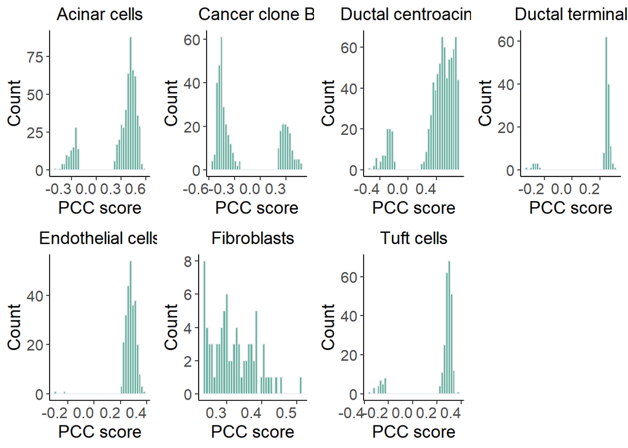

```r
score.barplot = Jointscore.barplot(Score = Joinscores, y.title="Count",
                                   x.title="PCC score",
                                   plot = FALSE, nrow = 1, fill="#69b3a2", color="#e9ecef")

pfig = cowplot::plot_grid(plotlist = score.barplot, nrow = 2)


pfig
```

## The number of ctHVGs

```r
temp = adjusted_t_p_values[,10]
Tcells   = names(temp[temp<0.05])
Tcells
```

```
## [1] "C20orf24" "Vps35"    "Xiap"
```

```r
temp = adjusted_t_p_values[,8]
MacroA  = names(temp[temp<0.05])
MacroA
```

```
## [1] "Apoe"  "Rbms1"
```

```r
temp =adjusted_t_p_values[,7]
fibro = names(temp[temp<0.05])
length(fibro)
```

```
## [1] 82
```

```r
temp =adjusted_t_p_values[,6]
Endo = names(temp[temp<0.05])
length(Endo)
```

```
## [1] 262
```

**Notes** We first define expressed genes in the Macrophages or T cells and NK cells (sender) and malignant cells (receiver). Genes are considered to be expressed within one cell type if their log2-transformed mean TPM (transcript per kilobase million) values are greater than 4, following the same criterion as in the NicheNet tutorial. The mean TPM value for each cell type is calculated based on the cell-type-specific gene expression of spots with the corresponding proportion greater than 0.05 within the focused spots.

```r
lr_network <- readRDS("./realdata/LR_analysis/lr_network_human_21122021.rds")

## ligand-target matrix denoting regulatory potential scores between ligands and targets (ligands in columns)

ligand_target_matrix <-  readRDS("./realdata/LR_analysis/ligand_target_matrix_nsga2r_final.rds")
```

**Notes:** Filtering Expressed Genes

```r
# Define genes and filter spots based on criteria
keep_genes <- rownames(stged$F_list[[2]])
keep_spots_Macro <- stged$beta[,11] > 0.05
keep_spots_Malignant <- stged$beta[,2] > 0.05
keep_spots_T <- stged$beta[,19] > 0.05

# Identify expressed genes for T cells, macrophages, and malignant cells
expressed_genes_T <- keep_genes[log2(rowMeans(stged$F_list[[19]][,keep_spots_T, drop = FALSE] * 1e6) + 1) >= 4]

expressed_genes_Macro <- keep_genes[log2(rowMeans(stged$F_list[[11]][,keep_spots_Macro, drop = FALSE] * 1e6) + 1) >= 4]
expressed_genes_Malignant <- keep_genes[log2(rowMeans(stged$F_list[[2]][,keep_spots_Malignant, drop = FALSE] * 1e6) + 1) >= 4]
```

**Notes:**The gene set of interest comprises the identified potential interaction-changed genes, encompassing both significantly positively correlated genes and significantly negatively correlated genes.

```r
# Convert gene names and intersect with ligand-target matrix
geneset_ctHVG_macor <- intersect(convert_alias_to_symbols(toupper(MacroA), "human", verbose = FALSE), colnames(ligand_target_matrix))

geneset_ctHVG_Tcell <- intersect(convert_alias_to_symbols(toupper(Tcells), "human", verbose = FALSE), colnames(ligand_target_matrix))

length(geneset_ctHVG_macor)
```

```
## [1] 1
```

```r
length(geneset_ctHVG_Tcell)
```

```
## [1] 0
```

**Notes:**

```r
# Convert gene names and intersect with ligand-target matrix
test_genes <- rownames(stged$F_list[[2]])[rowSums(stged$F_list[[2]]) != 0]

background_expressed_genes <- intersect(convert_alias_to_symbols(toupper(test_genes), "human", verbose = FALSE), rownames(ligand_target_matrix))
```

**Notes:**The potential ligands are defined as ligands expressed in at least one immune cell type and for which at least one putative receptor is expressed in malignant cells.

```r
# Identify ligands and receptors from the ligand-receptor network
ligands <- lr_network %>% pull(from) %>% unique()

expressed_ligands_Macro <- intersect(ligands, expressed_genes_Macro)

receptors <- lr_network %>% pull(to) %>% unique()
expressed_receptors <- intersect(receptors, expressed_genes_Malignant)

# Identify potential ligands interacting with receptors

potential_ligands_Macro <- lr_network %>% filter(from %in% expressed_ligands_Macro & to %in% expressed_receptors) %>% pull(from) %>% unique()
```

**Notes:**We then perform NicheNet’s ligand activity analysis.

```r
# Predict ligand activities for macrophages
ligand_activities_macro <- predict_ligand_activities(
  geneset = geneset_ctHVG_macor,
  background_expressed_genes = background_expressed_genes,
  ligand_target_matrix = ligand_target_matrix,
  potential_ligands = potential_ligands_Macro
)

best_upstream_ligands_macro <- ligand_activities_macro %>% arrange(-aupr_corrected) %>% pull(test_ligand)
```

**Notes:**Assign specific ligands to cell types based on expression levels

```r
Macro_specific_ligands <- intersect(best_upstream_ligands_macro, expressed_ligands_Macro)
```

**Notes:** When inferring target genes of the ligands, we consider the top 100 targets of at least one ligand according to the prior model.

```r
# Infer target genes for macrophages
active_ligand_target_links_df_macro1 <- best_upstream_ligands_macro %>%
  lapply(get_weighted_ligand_target_links, geneset = geneset_ctHVG_macor, ligand_target_matrix = ligand_target_matrix, n = 200) %>%
  bind_rows()
active_ligand_target_links_df_macro <- best_upstream_ligands_macro %>%
  lapply(get_weighted_ligand_target_links, geneset = geneset_ctHVG_macor, ligand_target_matrix = ligand_target_matrix, n = 100) %>%
  bind_rows()
```

**Notes:** clear data

```r
 na.omit(active_ligand_target_links_df_macro)
```

```
## # A tibble: 1 × 3
##   ligand target weight
##   <chr>  <chr>   <dbl>
## 1 AGT    APOE   0.0408
```

```r
 na.omit(active_ligand_target_links_df_macro1)
```

```
## # A tibble: 3 × 3
##   ligand target weight
##   <chr>  <chr>   <dbl>
## 1 TNFSF9 APOE   0.0697
## 2 AGT    APOE   0.0408
## 3 LTB    APOE   0.0698
```